# GPoM : PreProcessing

Sylvain Mangiarotti & Mireille Huc

2017-04-04

## Pre-processing for global modelling

To apply the global modelling approach, a careful preprocessing may be necessary because time series derivatives are required during the modelling process. Derivatives will be computed automatically when using the `gPoMo` function. To avoid problems, a careful preprocessing should be applied beforehand to have more chance to obtain global models. This vignette aims to show simple examples of time series preprocessing for global modelling application. In particular, we show the usefulness to resample the data (in order to improve the quality of the derivatives) and some of the limitations that may be found, especially when considering derivatives of high degree.

In practice, other types of preprocessing may be necessary depending on the quality of the data set (time sampling and time series length length, level of noise, presence of gaps, etc.). The required preprocessing may also depend on other factors such as: the dimension of underlying dynamics, the number of observed time series, the degree of observability, etc.

## Single time series

When only one single time series is observed, a global model of canonical form may be expected:

$dX_1/dt = X_2$

$dX_2/dt = X_3$

$...$

$dX_n/dt = F(X_1, X_2, ..., X_n)$.

with $X_1$ the observed variable, $X_2$, $X_3$, etc. its successive derivatives. The GPoM package is based on polynomial formulations. For the present formulation, its aim is to obtain a polynomial approximation of the function $F$. An approximation of $F$ can be obtained using the `gPoMo` function (see vignette `III_Modelling`). In practice, the canonical form will require the computations of $n$ derivatives to have the following $n + 1$ time series: $(X_1, X_2, ..., X_n, dX_n/dt)$.

Chaotic systems are well adapted to illustrate the skills of the global modelling approach because they are not trivial study cases: they are nonlinear and their behavior is unpredictable at long term. The Rössler system introduced by Otto Rössler in 1976 is used here[^1]. This system is defined as:

$dx/dt = - y - z$

$dy/dt = x + a y$

$dz/dt = b + z (x - c)$.

One of the interests of this system is to have different degrees of observability depending on the variable considered. This degree of observability results from the system nonlinearities. The question of observability is of first importance for global modelling since, depending on it, the model reconstruction may be easy, hard or completely impossible[^2]. Time series of such equations can be easily generated with the GPoM package (see vignette `I_Generate`). A ready to use data set of the Rössler-1976 system is also provided in the package that can be directly loaded:

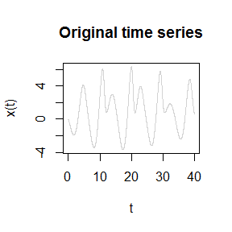

```r
    # load data
    data("Ross76")
    # plot
    tin <- Ross76[,1]
    data <- Ross76[,2:4]
    plot(tin, data[,1],
         xlab = 't', ylab = 'x(t)', main = 'Original time series',
         type='l', col = 'lightgray')
```

The time series $x(t)$ here plotted shows an irregular behavior and will be used hereafter to illustrate the global modelling in a canonical form. To illustrate the problem of time sampling, the time series is undersampled as follows:

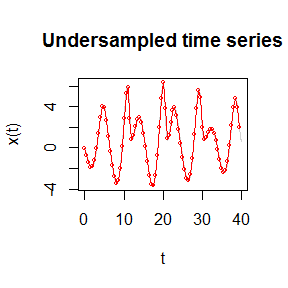

```r
    plot(tin, data[,1],
         xlab = 't', ylab = 'x(t)', main = 'Undersampled time series',
         type='l', col = 'lightgray')
    # subsampling:
    Ross76us <- Ross76[seq(1,4000,by=50),]
    # plot
    tus <- Ross76us[,1]
    datus <- Ross76us[,2:4]
    lines(tus, datus[,1], type='p', col='red', cex = 0.6)
    lines(tus, datus[,1], type='l', col='red')
```

The subsampling leads to loose some information. However, the general shape is obviously kept.

A spline can be used to resample the signal at the original sampling rate.

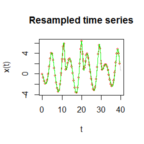

```r
    plot(tin, data[,1],
         xlab = 't', ylab = 'x(t)', main = 'Resampled time series',
         type='l', col = 'lightgray')
    # subsampling:
    Ross76us <- Ross76[seq(1,4000,by=50),]
    # plot
    tus <- Ross76us[,1]
    datus <- Ross76us[,2:4]
    lines(tus, datus[,1], type='p', col='red', cex = 0.6)
    lines(tus, datus[,1], type='l', col='red')
    #
    xout <- seq(min(tus), max(tus), by = 0.01)
    rspl <- spline(tus, y = datus[,1], method = "fmm", xout = xout)
    # plot resampled
    lines(rspl$x, rspl$y, type='l', col='green')
```

In the present case, the spline resampling appears quite efficient to retrieve the original signal. Note that alternative methods may be preferred depending on the dynamical behavior considered, on the rate of subsampling, on the signal quality, etc.)

The `drvSucc` function of the GPoM package aims to estimate the derivatives. It is based on the algorithm introduced by Savitzky and Golay in 1964[^3]. This function is applied to the three time series presented upper: (1) the original Rössler time series, (2) its undersampling, and (3) its resampling to the original sampling using splines.

```r
    # from original signal
    drv1 <- drvSucc(tin, data[,1], nDeriv=2)
    # from undersampled signal
    drv2 <- drvSucc(tus, datus[,1], nDeriv=2)
    # from resampled signal
    drv3 <- drvSucc(rspl$x, rspl$y, nDeriv=2)
```

The obtained time series for the first and second derivatives are plotted hereafter. Obviously, much of the original signal (in black) is lost when computing the derivatives from the undersampled time series (in red). Contrarily, much of the original signal is retrieved when computed from the resampled signal (in green), which clearly illustate the usefulness to resample the signal with appropriate algorithms before the computation of the derivatives.

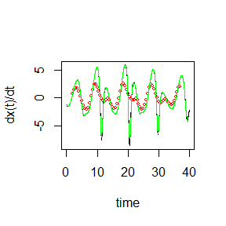

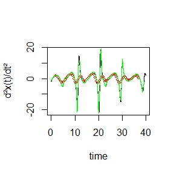

```r
    # plot resulting output as a function of time
    # output variable (smoothed) and its derivatives
#    plot(drv1$tout, drv1$seriesDeriv[,1], type='l', xlab = 'time', ylab = 'x(t)')
#    lines(drv2$tout, drv2$seriesDeriv[,1], type='p', cex = 0.6, col = 'red')
#    lines(drv3$tout, drv3$seriesDeriv[,1], type='l', col = 'green')
    # first derivative
    plot(drv1$tout, drv1$seriesDeriv[,2], type='l', xlab = 'time', ylab = 'dx(t)/dt')
    lines(drv2$tout, drv2$seriesDeriv[,2], type='p', cex = 0.6, col = 'red')
    lines(drv3$tout, drv3$seriesDeriv[,2], type='l', col = 'green')
    # second derivative
    plot(drv1$tout, drv1$seriesDeriv[,3], type='l', xlab = 'time', ylab = 'd²x(t)/dt²')
    lines(drv2$tout, drv2$seriesDeriv[,3], type='p', cex = 0.6, col = 'red')
    lines(drv3$tout, drv3$seriesDeriv[,3], type='l', col = 'green')
```

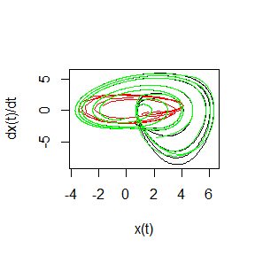

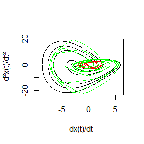

```r
    # output variable (smoothed) and its derivatives
     plot(drv1$seriesDeriv[,1], drv1$seriesDeriv[,2], type='l', xlab = 'x(t)', ylab = 'dx(t)/dt')
    lines(drv2$seriesDeriv[,1], drv2$seriesDeriv[,2], type='l', col = 'red')
    lines(drv3$seriesDeriv[,1], drv3$seriesDeriv[,2], type='l', col = 'green')
    # first derivative
#     plot(drv1$seriesDeriv[,1], drv1$seriesDeriv[,3], type='l', xlab = 'x(t)', ylab = 'd²x(t)/dt²')
#    lines(drv2$seriesDeriv[,1], drv2$seriesDeriv[,3], type='l', col = 'red')
#    lines(drv3$seriesDeriv[,1], drv3$seriesDeriv[,3], type='l', col = 'green')
    # second derivative
     plot(drv1$seriesDeriv[,2], drv1$seriesDeriv[,3], type='l', xlab = 'dx(t)/dt', ylab = 'd²x(t)/dt²')
    lines(drv2$seriesDeriv[,2], drv2$seriesDeriv[,3], type='l', col = 'red')
    lines(drv3$seriesDeriv[,2], drv3$seriesDeriv[,3], type='l', col = 'green')
```

This preprocessing illustrates (1) the usefulness to have a proper sampling of the observed process; (2) the usefulness to resample the observed time series at a better time sampling to improve the estimates of the derivatives; (3) some of the limitations reached for the derivatives of higher degree. Subsampling and resampling may have a direct impact when applying the global modelling techique and should thus be considered carefully when using the approach. Since the derivatives will be computed automatically when using the `gPoMo` function, it is important to keep in mind that their quality will directly depend on the characteristic of the time series provided as an input.

## Multiple time series

When several time series are available, global models of the following form can be expected:

$dX_1/dt = f_1(X_1, X_2, ..., X_n)$

$dX_2/dt = f_2(X_1, X_2, ..., X_n)$

$...$

$dX_n/dt = f_n(X_1, X_2, ..., X_n)$.

where the $X_i$, are the observed variables. The GPoM package can be used to obtain a polynomial approximation of the functions $f_i$ (see vignette `III_Modelling`). This formulation will require the computations of the first derivatives of each time series in order to have $(X_1, X_2, ..., X_n, dX_1/dt, dX_2/dt, ... dX_n/dt)$.

Here again the Rössler system (1976) is used to illustrate the skills of the global modelling approach.

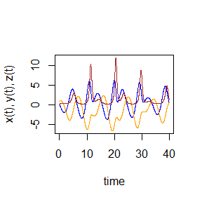

```r
    # load
    data("Ross76")
    # plot
    tin <- Ross76[,1]
    data <- Ross76[,2:4]
    plot(tin, data[,1],
         ylim = c(-6.5,12),
         type='l', col='blue', xlab = 'time', ylab = 'x(t), y(t), z(t)')
    lines(tin, data[,2], type='l',  col='orange')
    lines(tin, data[,3], type='l',  col='brown')
```

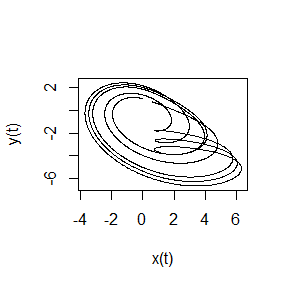

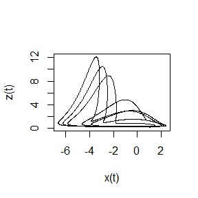

```r
    plot(data[,1], data[,2], type='l', xlab = 'x(t)', ylab = 'y(t)')
    #plot(data[,1], data[,3], type='l', xlab = 'y(t)', ylab = 'z(t)')
    plot(data[,2], data[,3], type='l', xlab = 'x(t)', ylab = 'z(t)')
```

For practical reasons, observations are often undersampled:

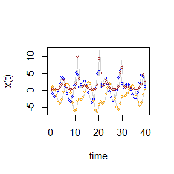

```r
    # plot
    tin <- Ross76[,1]
    data <- Ross76[,2:4]
    plot(tin, data[,1],
         ylim = c(-6.5,12),
         type='l', col='lightgray', xlab = 'time', ylab = 'x(t)')
    lines(tin, data[,2], type='l',  col='lightgray', xlab = 'time', ylab = 'y(t)')
    lines(tin, data[,3], type='l',  col='lightgray', xlab = 'time', ylab = 'z(t)')

    # undersampled data
    #
    # subsampling:
    Ross76us <- Ross76[seq(1,4000,by=75),]
    # plot
    tus <- Ross76us[,1]
    datus <- Ross76us[,2:4]
    lines(tus, datus[,1], type='p', cex = 0.5, col='blue')
    lines(tus, datus[,2], type='p', cex = 0.5, col='orange')
    lines(tus, datus[,3], type='p', cex = 0.5, col='brown')
```

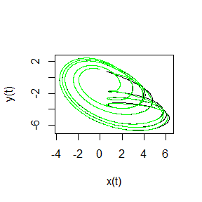

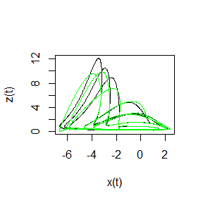

```r
    xout <- seq(min(tus), max(tus), by = 0.01)
    rsplx <- spline(tus, y = datus[,1], method = "fmm", xout = xout)
    rsply <- spline(tus, y = datus[,2], method = "fmm", xout = xout)
    rsplz <- spline(tus, y = datus[,3], method = "fmm", xout = xout)
    # plot resampled
    plot(data[,1], data[,2], type='l', xlab = 'x(t)', ylab = 'y(t)')
    lines(rsplx$y, rsply$y, type='l', col='green')
#    plot(data[,1], data[,3], type='l', xlab = 'y(t)', ylab = 'z(t)')
#    lines(rsplx$y, rsplz$y, type='l', col='green')
    plot(data[,2], data[,3], type='l', xlab = 'x(t)', ylab = 'z(t)')
    lines(rsply$y, rsplz$y, type='l', col='green')
```

Discrepancies related to the derivatives can be easily observed considering the derivative phase portraits. The skills of resampling is obviously good for variable $y$:

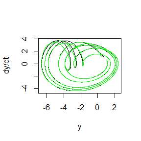

```r
    # derivatives
    # from original signal
    drv1x <- drvSucc(tin, data[,1], nDeriv=2)
    drv1y <- drvSucc(tin, data[,2], nDeriv=2)
    drv1z <- drvSucc(tin, data[,3], nDeriv=2)
    # from resampled signal
    drv3x <- drvSucc(rsplx$x, rsplx$y, nDeriv=2)
    drv3y <- drvSucc(rsply$x, rsply$y, nDeriv=2)
    drv3z <- drvSucc(rsplz$x, rsplz$y, nDeriv=2)
    # phase portraits plot for y:
    # (y, dy/dt) projection of the original signal (in black) and resampled signal (in green)
    plot(drv1y$seriesDeriv[,1], drv1y$seriesDeriv[,2], type='l', xlab = 'y', ylab = 'dy/dt')
    lines(drv3y$seriesDeriv[,1], drv3y$seriesDeriv[,2], type='l', col='green')
```

Resampling appears less efficient for variables $x$ and $z$:

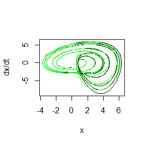

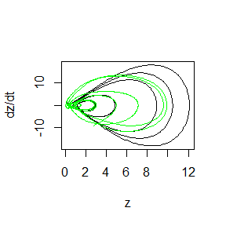

```r
    # phase portraits plot for x and z:
    # (x, dx/dt) projection of the original signal (in black) and resampled signal (in green)
    plot(drv1x$seriesDeriv[,1], drv1x$seriesDeriv[,2], type='l', xlab = 'x', ylab = 'dx/dt')
    lines(drv3x$seriesDeriv[,1], drv3x$seriesDeriv[,2], type='l', col='green')
    # phase portraits plots
    # (z, dz/dt) projection of the original signal (in black) and resampled signal (in green)
    plot(drv1z$seriesDeriv[,1], drv1z$seriesDeriv[,2], type='l', xlab = 'z', ylab = 'dz/dt')
    lines(drv3z$seriesDeriv[,1], drv3z$seriesDeriv[,2], type='l', col='green')
```

Although resampling with splines may not permit to reconstruct the original signal perfectly, from a practical point of view, it appears necessary in many cases, and it is in practice a rather efficient way to deal with subsampling. This type of resampling could be efficiently used for applying the global modelling technique both from single time series[^4], and multiple time series[^5] [^6].

## Next step

Once the time series have been carefuly prepared, the global modelling technique can be tried. This is presented in the next vignette `III_Modelling`.

[^1]: O. Rössler, 1976. An Equation for Continuous Chaos, Physics Letters, 57A(5), p. 397-398.
[^2]: C. Letellier, L. A. Aguirre, & J. Maquet, 2005. Relation between observability and differential embeddings for nonlinear dynamics, Phys. Rev. E 71(6), 066213.
[^3]: A. Savitzky & M. J. Golay, 1964. Smoothing and differentiation of data by simplified least squares procedures, Anal. Chem. 36(8), 1627–1639.
[^4]: S. Mangiarotti, L. Drapeau, & C. Letellier, 2014. Two chaotic global models for cereal crops cycles observed from satellite in Northern Morocco, Chaos, 24, 023130.
[^5]: S. Mangiarotti, 2015. Low dimensional chaotic models for the plague epidemic in Bombay (1896–1911), Chaos, Solitons, Fractals 81(A), 184–196.
[^6]: S. Mangiarotti, M. Peyre & M. Huc, 2016. A chaotic model for the epidemic of Ebola virus disease in West Africa (2013–2016). Chaos, 26, 113112.